```python
import pandas as pd

# Load the Excel data
df = pd.read_excel('bikes_data.xlsx')
```

# Bike Rental Analysis - Bay Wheels

This project explores bike rental data to reveal trends and pattenrs in user behavior and in weather influences.

The sets of data include time, weather and rental count information. The approach to this assignment will focus on drawing important insights rather than techinal complexity.

The focus is to realize **when and why** people rent bikes and to what extent weather and enviromental factors such as **temperature** or **humidity** intervein. This will enable the bike sharing company to match their strategy with market demand.

The analysis comprises visual representation of trends, data-driven reasoning and recommendations that could support management decisions.

According to my conclusions, I have identifed three most relevant insights about user beahviour, ideal conditions and strategic planning.

## Relevant Insights

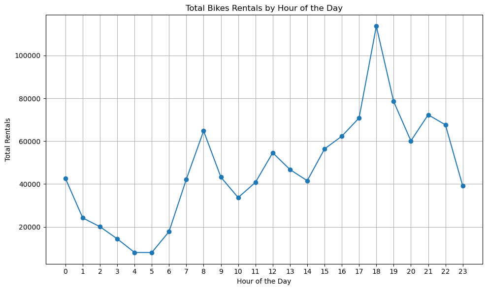

```python
# This block tells us at what time of the day users rent bikes more often.

# Group the total rentals
hourly_rentals = df.groupby('Hour')['RENTALS'].sum()

# Visualize the total rentals by hours
import matplotlib.pyplot as plt

plt.figure(figsize=(10, 6)) # Set the size of the plot
plt.plot(hourly_rentals.index, hourly_rentals.values, marker='o') # Plot line with dots
plt.title('Total Bikes Rentals by Hour of the Day') # Title of the graph
plt.xlabel('Hour of the Day') # X-axis label
plt.ylabel('Total Rentals') # Y-axis label
plt.grid(True) # Add grid for easire reading
plt.xticks(range(0,24)) #Shows all 24 hours on the x-axis
plt.tight_layout()
plt.show()
```

The above line graph displays the total number of bike rental per each hour. Overall the peak of usage is at 8 AM and again betwenn 5 to 6 Pm. These are normal commuting hours, that indicates that users are mainly renting bikes to go to and from work.

Additionally, it can be seen that the number of rentals decreases during late-night hours, perhaps because of safety matters, less transportation needs and reduce visibility. This trend is important because it shows at what time of the day are more bikes being rented, which means that it may influence the resource allocation of the company during the time period in question.

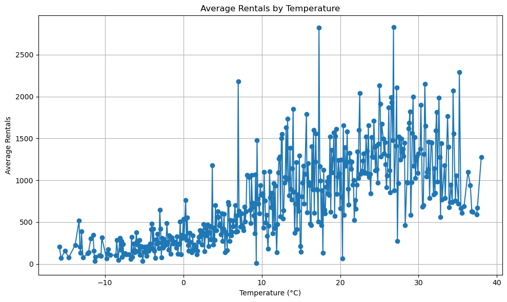

```python
# This block analyzes the relationship between temperature and bike rentals

# Group data by temperature and calculate average rentals at each temperature value
temp_rentals = df.groupby('Temperature')['RENTALS'].mean()

#Plot temperature vs average rentals
plt.figure(figsize=(10, 6))
plt.plot(temp_rentals.index, temp_rentals.values, marker='o')
plt.title('Average Rentals by Temperature')
plt.xlabel('Temperature (°C)')
plt.ylabel('Average Rentals')
plt.grid(True)
plt.tight_layout()
plt.show()
```

## Number of Average Rentals Per Temperature

The above line graph shows that the numbers of bike rentals is higher as the temperatures increases. On the other hand, the number of bike rentals considerably decreases when tempearture are bellow 0ºC.

Overall, moderate weather has a positive effect on bike rental demand, and thus provides useful information for marketing and operational decisions.

```python
import matplotlib.pyplot as plt
```

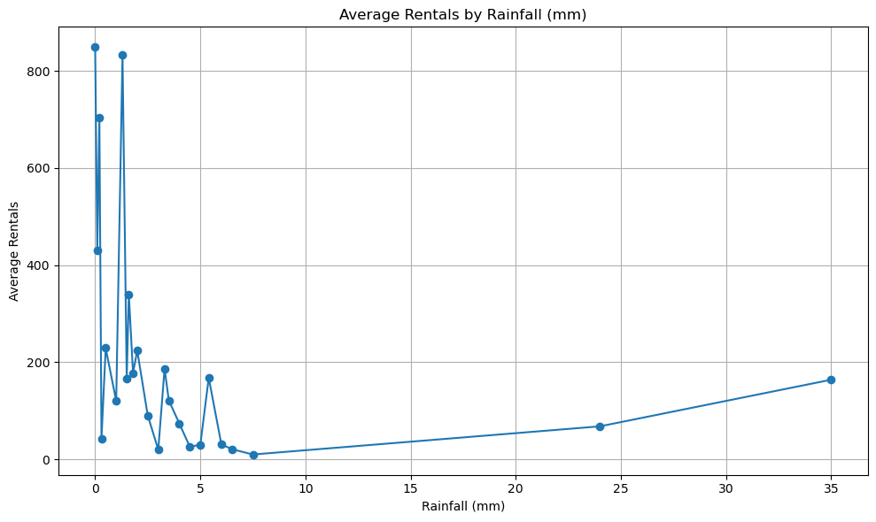

```python
#This block analyzes the relationship between rainfall and average bike rentals

#Group data by rainfall and calculate average rentals
rain_rentals = df.groupby('Rainfall')['RENTALS'].mean()

#Plot rainfall vs average rentals
plt.figure(figsize=(10, 6))
plt.plot(rain_rentals.index, rain_rentals.values, marker='o')
plt.title('Average Rentals by Rainfall (mm)')
plt.xlabel('Rainfall (mm)')
plt.ylabel('Average Rentals')
plt.grid(True)
plt.tight_layout()
plt.show()
```

## Number of Average Rentals Per Amount of Rainfall (mm)

The above line graph displays the number of average bike rentals per mm of rainfall. Overall, when rainfall increases, theres is a sharp fall in the number of rentals.

This should come as little surprise, since biking in the rain is usually unpleasant and possibly dangerous, especially for leisure riders or commuter cyclists who lack wet weather gear.

Even light rainfall appears to negatively impact rental volume, which suggests that users are highly sensitive to changes in weather.

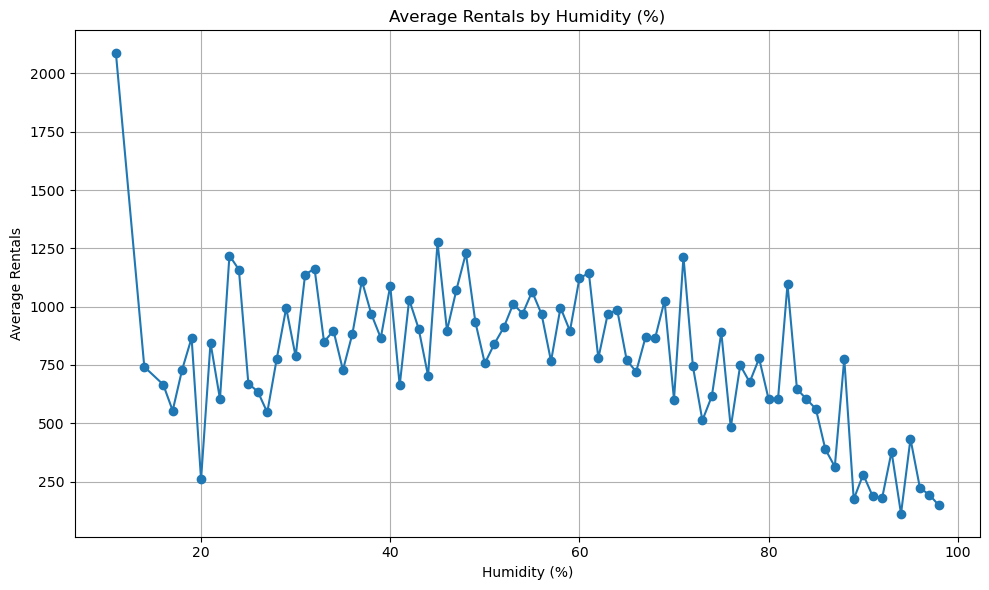

```python
# This block analyzes how humidity levels affect the number of bike rentals

# Group by humidity and calculate average rentals
humidity_rentals = df.groupby('Humidity')['RENTALS'].mean()

# Plot humidity vs average rentals
plt.figure(figsize=(10, 6))
plt.plot(humidity_rentals.index, humidity_rentals.values, marker='o')
plt.title('Average Rentals by Humidity (%)')
plt.xlabel('Humidity (%)')
plt.ylabel('Average Rentals')
plt.grid(True)
plt.tight_layout()
plt.show()
```

## Number of Average Rentals Per Humidity Percentage

The above graph represents the number of average bike rentals per humidity percentage . It can be seen that when humidity ranges from 40% to 60%, rental numbers are higher.

However, particularly at around 70% or 80% plus, the average number of rentals starts to decrease. This may be due to the discomfort associated with sticky or muggy weather, meaning that biking becomes unappealing — especially for casual or non-commuter users.

This pattern indicates that extreme humidity is a limiting factor for outdoor activity. The company could use this insight to adjust expectations and operations during high-humidity days, or explore strategies like offering discounts to encourage usage during these times.

## Why Are the Majority of Users Renting Bicycles

According to the distribution of rental times, the majority of users rented their bikes during the normal commute times, mainly between 8 AM and 5 to 6 PM. These spikes appear to indicate that thousands of users are using bikes for daily mobility, probably going to work or school.

Similar to some global urban bike-share trends, this behavior reflects convenience, cost savings, and a means of escaping traffic, all of which make biking an attractive alternative here. We can see further evidence of that conclusion in the way rentals are plummeting during hours that are not between commutes.

In general, most users are probably busy people using bikes as a functional commuting method through the city in peak hours.

## Ideal Weather Conditions for High Bike Rental Demand

Both rentals are adversely affected by rainfall and high humidity. Minor rainfall also seems to lead to a significant decrease in observed usage too, along with extremely humid days (>80%). Perhaps for safety or comfort reasons, these factors seem to deter casual and commuter bikers.

With this insights the company is able to plan marketing, maintenance, and the availability of the fleet around these conditions.

## Strategic Recommendations Based on the Analysis

Moreover,since there is a correlation between low demadn and bad weather, the company could decrease the number of bikes deployed on bad weather days or offer discounts during such days to boost usage. Predictive weather-based planning could decrease costs and unnecessary bike repositioning or maintenance.

Working professionals or people who do not own a car or a motorbike should be targeted in marketing campaings during mild weather months, as well as promotions to increase costumer satisfaction.

## Conclusion

Identifying and interpreting these patterns will allow the company to increase the optimization of its operations, improve user satisfaction and align business strategies with real user needs.

## Sources To Support Insights (APA Format)

National Association of City Transportation Officials (2019) *Shared Micromobility in the U.S: 2019* https://nacto.org/publication/shared-micromobility-report-2019/

Transport for London. (2015). *Attitudes towards cycling: Autum 2015*. https://tfl.gov.uk/cdn/static/cms/documents/attitudes-towards-cycling-sept%202015-summary.pdf